# Human Activity Recognition

Javier Prieto

18 de septiembre de 2014

## Summary

In this study, we predict the type of activity that 6 participans do based on data from accelerometers on their belt, forearm, arm, and dumbell. The use of random forest lead us to a near-optimal model that distinguishes between 5 activity classes achiving an accuracy greater than 99%

## Cleaning and splitting the data

```r
library(caret)
## Read training data
data<-read.csv("pml-training.csv")
## Read test data
test<-read.csv("pml-testing.csv")
## Remove first 7 columns with username, timestamps and so on
test<-test[,8:ncol(test)]
## Select only the columns with non-NA values in the test data
test<-test[,names(test)[colSums(is.na(test))==0]]
## Keep the same columns in the training set as in the test data
data<-data[,c(names(test)[1:ncol(test)-1],"classe")]
```

After that, we split the data into the training and testing sets, with a proportion of 60% to 40%, respectively.

```r
## Divide the training set into training and testing samples
inTrain<-createDataPartition(y=data$classe,p=0.6,list=FALSE)
training<-data[inTrain,] # Training samples
testing<-data[-inTrain,] # Testing samples
```

## Training the model

In this section, we apply the Breiman’s randomForest algorithm to the training set.

```r
## Set the seed to a fix value
set.seed(125)
## Load randomForest library
library(randomForest)
## Apply random Forest algorithm
modFit<-randomForest(classe~.,data=training,proximity=TRUE)
```

## Validating the model

In the following, we predict the class of activity from the obtained testing set based on the fitted model. Next, we check the accuracy achieved by means of the confusion matrix.

```r
## Predict the classes in the testing set with the trained model
pred<-predict(modFit,testing)
## Evalute the results
confusionMatrix(data=pred, testing$classe)
```

```
## Confusion Matrix and Statistics
##
##           Reference
## Prediction    A    B    C    D    E
##          A 2230   10    0    0    0
##          B    2 1506    5    0    0
##          C    0    2 1356   17    0
##          D    0    0    7 1269    2
##          E    0    0    0    0 1440
##
## Overall Statistics
##
##                Accuracy : 0.994
##                  95% CI : (0.992, 0.996)
##     No Information Rate : 0.284
##     P-Value [Acc > NIR] : <2e-16
##
##                   Kappa : 0.993
##  Mcnemar's Test P-Value : NA
##
## Statistics by Class:
##
##                      Class: A Class: B Class: C Class: D Class: E
## Sensitivity             0.999    0.992    0.991    0.987    0.999
## Specificity             0.998    0.999    0.997    0.999    1.000
## Pos Pred Value          0.996    0.995    0.986    0.993    1.000
## Neg Pred Value          1.000    0.998    0.998    0.997    1.000
## Prevalence              0.284    0.193    0.174    0.164    0.184
## Detection Rate          0.284    0.192    0.173    0.162    0.184
## Detection Prevalence    0.285    0.193    0.175    0.163    0.184
## Balanced Accuracy       0.999    0.995    0.994    0.993    0.999
```

As we can appreciate in the results, the achieved accuracy in the testing set is greater than 99%. Next figure represents the error rate in logarithmic units.

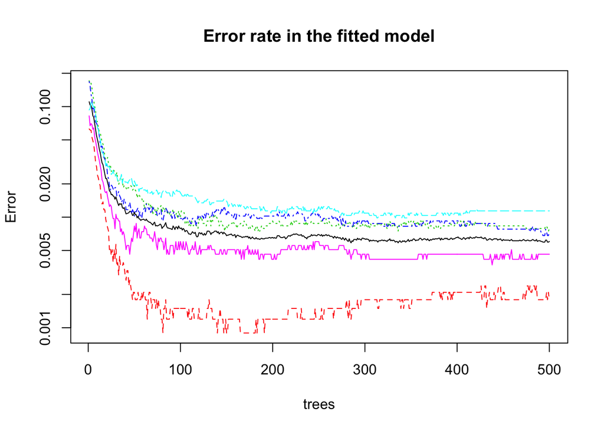

```r
plot(modFit,log="y",main="Error rate in the fitted model")
```

## 20 test cases

Finally, we apply the fitted model to the 20 test cases and save them in individual files by defining the function *pml_write_files*.

```r
## Predict the classes in the 20 cases of the given test set
answers<-predict(modFit,test)
## Define function for project submission
pml_write_files = function(x){
n = length(x)
for(i in 1:n){
filename = paste0("problem_id_",i,".txt")
write.table(x[i],file=filename,quote=FALSE,row.names=FALSE,col.names=FALSE)
}
}
# Generate files to submit
pml_write_files(answers)
```

## Conclusion

Random forest algorithm is a good choice for predicting models with more than 2 classes and numerous predictors. Based on the given data we achieve an accuracy of 99%, correctly predicting the 20 test cases.